# Data Analysis of High School Attitudinal Survey

## Data

Code book variables used to address this question. Everything is documented (*especially for your future self* who doesn’t have as good a memory as you think).

```
ADDHEALTH: WAVE4 IN-HOME INTERVIEW CODE BOOK
Wave IV Section 15: Suicide, Sexual Experiences, & Sexually Transmitted Diseases

  H4ED1 (gradHS)
  1. What is your high school graduation status?
    1 Finished high school with diploma
    2 Earned a high school equivalency degree (GED)
    3  Earned a Certificate of attendance or a certificate of completion
    4 Did not receive hs diploma, GED or other certificate
    6 Refused
    8 don't know

* 1st New Binary Var: * gradHS Graduate HS = 1==1; Non Graduate HS = 0 == vs. 0;

  H$ED2 (gradBA)
  9. What is the highest level of education that you have acheived to date?
    1 8th grade or less
    2 Some high school
    3 high school graduate
    4 Some vocationalized training (after high school)
    5 Completed vocationalized training (after high school)
    6 Some College
    7 Completed a Bachelor's
    8 Some Graduate School
    9 Completed a master's degree
    10 Some graduate training beyond a master's degree
    11 Completed a doctoral degree

Constructed variables
* gradBA >= 7
* education >=6
```

We create a data frame with nicely named variables, code and remove missing values, and code a binary variable for “Graduate College (BA)” (`gradBA`).

```r
str(addhealth.sub.f)
```

```
'data.frame':   3694 obs. of  40 variables:
 $ AID                 : Factor w/ 6504 levels "57100270","57101310",..: 2 8 10 12 17 18 20 21 22 24 ...
 $ BirthMonth          : num  11 3 6 1 4 9 8 7 10 1 ...
 $ SurveyMonth         : num  5 6 8 5 7 5 7 6 5 8 ...
 $ BirthYear           : num  76 81 81 79 79 82 76 79 80 82 ...
 $ BirthDay            : num  18 5 12 10 15 6 17 5 0 5 ...
 $ SurveyYear          : num  95 95 95 95 95 95 95 95 95 95 ...
 $ SurveyDay           : num  5 7 3 20 19 25 20 8 20 15 ...
 $ Age                 : num  18.5 14.2 14.2 16.3 16.2 ...
 $ Sex                 : Factor w/ 2 levels "1","2": 2 1 1 1 2 1 2 2 2 2 ...
 $ ExpectCollege       : Factor w/ 5 levels "1","2","3","4",..: 1 2 4 3 5 5 5 5 4 5 ...
 $ Working             : Factor w/ 2 levels "0","1": 1 1 1 2 2 1 1 2 1 2 ...
 $ HoursWorked         : num  0 6 0 3 4 0 20 10 0 40 ...
 $ Race                : Factor w/ 9 levels "1","2","3","4",..: 7 7 7 7 7 7 7 7 7 7 ...
 $ White1              : Factor w/ 4 levels "0","1","6","8": 1 2 2 1 2 2 2 2 1 1 ...
```

[output cut: 29 more lines]

```r
summary(addhealth.sub.f$gradBA)
```

```
  No BA BA Grad
   2359    1335
```

```r
levels(addhealth.sub.f$gradBA)
```

```
[1] "No BA"   "BA Grad"
```

```r
gradBA <- ifelse(addhealth.sub.f$gradBA=="BA Grad", 1, 0)
addhealth.sub.f$gradBA <- gradBA
#addhealth.sub.f$gradBA <- as.numeric(addhealth.sub.f$gradBA)

summary(addhealth.sub.f$ExpectCollegeNum)
```

```
   Min. 1st Qu.  Median    Mean 3rd Qu.    Max.
  1.000   4.000   5.000   4.267   5.000   5.000
```

```r
is.numeric(addhealth.sub.f$ExpectCollegeNum)
```

```
[1] TRUE
```

```r
summary(addhealth.sub.f$ParenConcernMean)
```

```
   1    2    3    4    5
 163   99  502 1076 1854
```

```r
is.numeric(addhealth.sub.f$ParenConcernMean)
```

```
[1] FALSE
```

```r
addhealth.sub.f$ParenConcernMean <- as.numeric(addhealth.sub.f$ParenConcernMean)
is.numeric(addhealth.sub.f$ParenConcernMean)
```

```
[1] TRUE
```

```r
is.numeric(addhealth.sub.f$gradBA)
```

```
[1] TRUE
```

```r
is.numeric(addhealth.sub.f$HoursWorked)
```

```
[1] TRUE
```

```r
table(addhealth.sub.f$HoursWorked)
```

```
   0    1    2    3    4    5    6    7    8    9   10   11   12   13   14
1800   90  172  134  129  151   86   48   77   16  120    3   63    8   18
  15   16   17   18   19   20   21   22   23   24   25   26   27   28   29
 118   27    7   35    5  219   10    8    7   13   89    2    5   13    2
  30   31   32   33   34   35   36   37   38   39   40   42   43   45
  99    3   11    2    1   33    7    1    1    1   50    2    1    7
```

```r
addhealth.sub.f$HoursWorked[addhealth.sub.f$HoursWorked == 0] <- NA
dim(addhealth.sub.f)
```

```
[1] 3694   40
```

```r
addhealth.sub.f <-na.omit(addhealth.sub.f)
dim(addhealth.sub.f)
```

```
[1] 1894   40
```

```r
# assign to a data frame
#summary(addhealth.sub.f$ExpectCollegeNum)
#df.ExpectCollegeNum.gradBA <- data.frame(ExpectCollegeNum = addhealth.sub.f$ExpectCollegeNum
#                        , gradBA = addhealth.sub.f$gradBA)
# assign to a data frame
summary(addhealth.sub.f$HoursWorked)
```

```
   Min. 1st Qu.  Median    Mean 3rd Qu.    Max.
   1.00    4.00   10.00   13.02   20.00   45.00
```

```r
df.HoursWorked.gradBA <- data.frame(HoursWorked = addhealth.sub.f$HoursWorked
                        , gradBA = addhealth.sub.f$gradBA)
str(df.HoursWorked.gradBA)
```

```
'data.frame':   1894 obs. of  2 variables:
 $ HoursWorked: num  6 3 4 20 10 40 10 2 8 15 ...
 $ gradBA     : num  0 0 1 0 1 0 0 0 0 0 ...
```

```r
# plot histograms for each condition and fit a logistic curve
# install.packages("popbio")
library(popbio)
#summary(df.ExpectCollegeNum.gradBA$gradBA)
summary(df.HoursWorked.gradBA$HoursWorked)
```

```
   Min. 1st Qu.  Median    Mean 3rd Qu.    Max.
   1.00    4.00   10.00   13.02   20.00   45.00
```

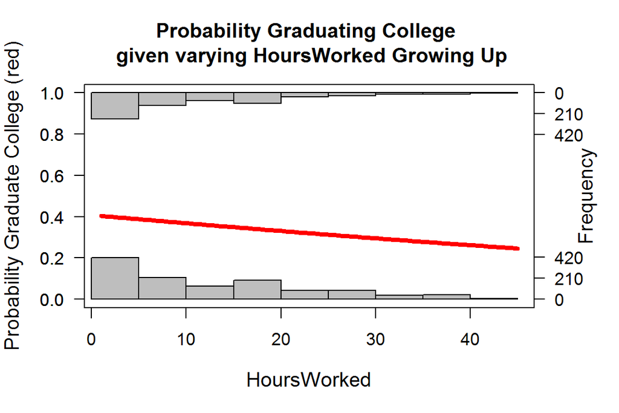

```r
#logi.hist.plot(df.ExpectCollegeNum.gradBA$ExpectCollegeNum, df.ExpectCollegeNum.gradBA$gradBA
#              , logi.mod = 1 # logistic fit
#              , type = "hist", rug = FALSE, boxp = FALSE
#
#              , col = "gray"
#              , mainlabel = "Probability Graduating College \n given varying College Expectation"
#              , ylabel = "Probability Graduate College (red)"
#              #, ylabel2 = "Frequency"
#              , xlabel = "College Expectation")
logi.hist.plot(df.HoursWorked.gradBA$HoursWorked, df.HoursWorked.gradBA$gradBA
              , logi.mod = 1 # logistic fit
              , type = "hist", rug = FALSE, boxp = FALSE

              , col = "gray"
              , mainlabel = "Probability Graduating College \n given varying HoursWorked Growing Up"
              , ylabel = "Probability Graduate College (red)"
              #, ylabel2 = "Frequency"
              , xlabel = "HoursWorked")
```

```r
  # Note (11/1/2015):
  # there's a bug in the plotting function
  #   (I've emailed the package maintainer and it's been fixed in the next update)
  # if the boxplots are on (boxp=TRUE), then both ylabels are ylabel2.
#?logi.hist.plot
```

```r
library(plyr)
#df.ExpectCollegeNum.gradBA.sum <- ddply(df.ExpectCollegeNum.gradBA, "ExpectCollegeNum", summarise
#                        , Total = length(gradBA)
#                        , Success = sum(gradBA)
#                        )
df.HoursWorked.gradBA.sum <- ddply(df.HoursWorked.gradBA, "HoursWorked", summarise
                        , Total = length(gradBA)
                        , Success = sum(gradBA)
                        )
# create estimated proportion of preg for each age group
#df.ExpectCollegeNum.gradBA.sum$p.hat <- df.ExpectCollegeNum.gradBA.sum$Success / df.ExpectCollegeNum.gradBA.sum$Total
df.HoursWorked.gradBA.sum$p.hat <- df.HoursWorked.gradBA.sum$Success / df.HoursWorked.gradBA.sum$Total

#df.ExpectCollegeNum.gradBA.sum
df.HoursWorked.gradBA.sum
```

```
   HoursWorked Total Success     p.hat
1            1    90      38 0.4222222
2            2   172      76 0.4418605
3            3   134      49 0.3656716
4            4   129      46 0.3565891
5            5   151      53 0.3509934
6            6    86      33 0.3837209
7            7    48      18 0.3750000
8            8    77      22 0.2857143
9            9    16       8 0.5000000
10          10   120      47 0.3916667
11          11     3       2 0.6666667
12          12    63      24 0.3809524
13          13     8       3 0.3750000
14          14    18       4 0.2222222
```

[output cut: 29 more lines]

```
1. Logistic regression.
Select a binary reponse and continue explanatory/predictor variable.

* (1 p) Summarize the $\hat{p}$ values for each value of the $x$-variable.  Also, calculate the empirical logits.
```

Plots on the probability scale should follow a sigmoidal curve (a little difficult to see here). Note that the overlayed reference curve (red) is a weighted smoothed curve (loess), not the model fit.

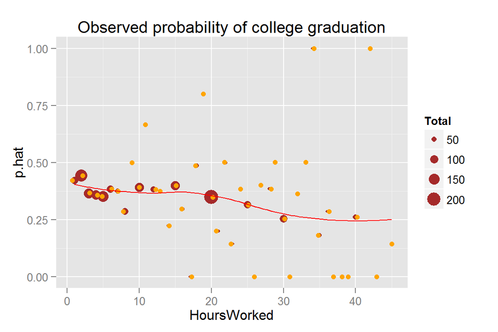

```r
#library(ggplot2)
#p <- ggplot(df.ExpectCollegeNum.gradBA.sum, aes(x = ExpectCollegeNum, y = p.hat))
#p <- p + geom_point(aes(size = Total))
#p <- p + geom_smooth(se = FALSE, colour = "red", aes(weight = Total))  # just for reference
#p <- p + expand_limits(y = 0) + expand_limits(y = 1)
#p <- p + labs(title = "Observed probability of college graduation")
#print(p)
library(ggplot2)
p <- ggplot(df.HoursWorked.gradBA.sum, aes(x = HoursWorked, y = p.hat))
p <- p + geom_point(aes(size = Total), color = "brown")
p <- p + geom_point(position = position_jitter(width=0.3), colour = "orange")
p <- p + geom_smooth(se = FALSE, colour = "red", aes(weight = Total))  # just for reference
p <- p + expand_limits(y = 0) + expand_limits(y = 1)
p <- p + labs(title = "Observed probability of college graduation")
print(p)
```

On the logit scale, if points follow a straight line, then we can fit a simple linear logistic regression model. Note that the overlayed reference straight line (blue) is from weighted least squares (not the official fitted line), and the curve (red) is a weighted smoothed curve (loess). Both lines are weighted by the total number of observations that each point represents, so that points representing few observations don’t contribute as much as points representing many observations

[output not shown]

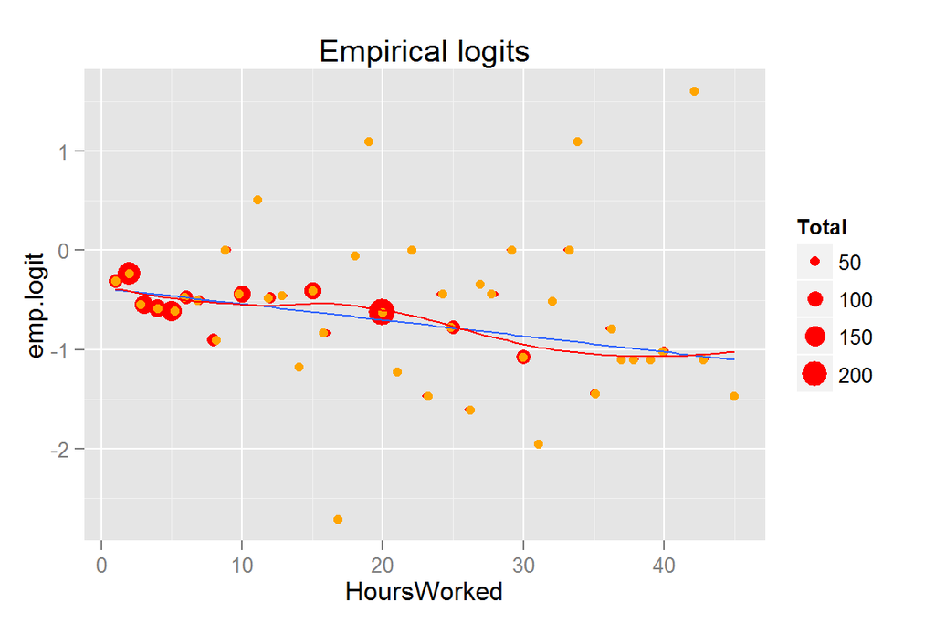

```
__logit-vs-$x$ plot__
* (1 p) Describe the logit-vs-$x$ plot.  Is it linear?  If not, consider a transformation of $x$ to improve linearity; describe the transformation you chose if you needed one.
ANSWER: In my opinion, a straight line would sufficiently well (not optimal).  There are details that are missed by a linear model, such as the apparent double-se,  inverse "S" curve.
```

```r
#summary()
# emperical logits
#df.ExpectCollegeNum.gradBA.sum$emp.logit <- log((    df.ExpectCollegeNum.gradBA.sum$p.hat + 0.5/df.ExpectCollegeNum.gradBA.sum$Total) /
#                                 (1 - df.ParenConcernMean.gradBA.sum$p.hat + 0.5/df.ParenConcernMean.gradBA.sum$Total))
#
df.HoursWorked.gradBA.sum$emp.logit <- log((    df.HoursWorked.gradBA.sum$p.hat + 0.5/df.HoursWorked.gradBA.sum$Total) /
                                 (1 - df.HoursWorked.gradBA.sum$p.hat + 0.5/df.HoursWorked.gradBA.sum$Total))
#p <- ggplot(df.ExpectCollegeNum.gradBA.sum, aes(x = ExpectCollegeNum, y = emp.logit))
#p <- p + geom_point(aes(size = Total))
#p <- p + stat_smooth(method = "lm", se = FALSE, aes(weight = Total))  # just for reference
#p <- p + geom_smooth(se = FALSE, colour = "red", aes(weight = Total))  # just for reference
#p <- p + labs(title = "Empirical logits")
#print(p)
library(ggplot2)
p <- ggplot(df.HoursWorked.gradBA.sum, aes(x = HoursWorked, y = emp.logit))
p <- p + geom_point(aes(size = Total), color = "red")
p <- p + geom_point(position = position_jitter(width=0.3), colour = "orange")
p <- p + stat_smooth(method = "lm", se = FALSE, aes(weight = Total))  # just for reference
p <- p + geom_smooth(se = FALSE, colour = "red", aes(weight = Total))  # just for reference
p <- p + labs(title = "Empirical logits")
print(p)
```